# INFO 6270 Final Project

**Identifying Areas with Airbnb Listings in New Brunswick for Further Investigation**

INFO 6270: Final Project

Municipalities around the world are exploring ways of regulating home-sharing platforms such as Airbnb. Some municipalities allow Airbnb and other home-sharing with no regulations, while other municipalities may ban Airbnb altogether. If Airbnb is to be regulated within a municipality, the regulatory decisions should be based in evidence (Quatronne et al., 2016).

There can be both positive and negative impact from Airbnb. For example, Airbnb can increase visitors to a local area. At the same time, however, property owners may choose to list a short-term rental as compared to a long-term rental due to increased revenue (Wegmann & Jiao, 2017). There can also be specific impacts on the housing market. According to Wegmann & Jiao (2017), whole-unit rentals impact the housing market more than a single room rental (like a spare room). Whole-unit rentals can also significantly impact the housing market if they are rented for a large portion of the year (Wegmann & Jiao, 2017). Using a data repository from Inside Airbnb, these variables will be measured and used to filter out places in New Brunswick where staff should consider regulating Airbnb. These variables are:

1. Whole-unit listings,

2. Listings held by multi-unit hosts, and

3. High occupancy listings (>25%).

The aim of this project is to find the places in New Brunswick with the highest number of listings based on these criteria. When these places are identified, city/town staff can decide on regulations that suit their needs accordingly.

The data for this project is contained in a .csv file in the downloads folder. We want to import pandas to transform the data into tables. To do this, we will use the code below.

```python
import pandas as pd # import pandas

import numpy as np # import numpy

nb = pd.read_csv('downloads/data/NBdata.csv') # command pandas to import the data
```

Now let's look at the data to find areas to be cleaned up.

```python
#Retrieve the first 5 rows of data.
nb.head()
```

|  | id | listing_url | scrape_id | last_scraped | name | summary | space | description | experiences_offered | neighborhood_overview | ... | instant_bookable | is_business_travel_ready | cancellation_policy | require_guest_profile_picture | require_guest_phone_verification | calculated_host_listings_count | calculated_host_listings_count_entire_homes | calculated_host_listings_count_private_rooms | calculated_host_listings_count_shared_rooms | reviews_per_month |
| --- | --- | --- | --- | --- | --- | --- | --- | --- | --- | --- | --- | --- | --- | --- | --- | --- | --- | --- | --- | --- | --- |
| 0 | 75065 | https://www.airbnb.com/rooms/75065 | 2.020010e+13 | 2020-01-28 | Bay cottage on Passamaquoddy bay | NaN | This beautiful two bedroom getaway cottage is ... | This beautiful two bedroom getaway cottage is ... | none | NaN | ... | f | f | strict_14_with_grace_period | f | f | 1 | 1 | 0 | 0 | 0.27 |
| 1 | 145013 | https://www.airbnb.com/rooms/145013 | 2.020010e+13 | 2020-01-28 | Lobster Lane Cottage: private beach | This cottage rents Sunday to Sunday in high se... | Reservations are now being taken for Summer 20... | This cottage rents Sunday to Sunday in high se... | none | Caissie Cape is a small village with few store... | ... | f | f | strict_14_with_grace_period | f | f | 1 | 1 | 0 | 0 | 0.09 |
| 2 | 261800 | https://www.airbnb.com/rooms/261800 | 2.020010e+13 | 2020-01-29 | Furnished Executive Close to City | Beautifully restored, , professional neighbour... | Large bright 2 bedrm , beautifully Furnished, ... | Beautifully restored, , professional neighbour... | none | Established neighbourhood, Docters offices, ch... | ... | f | f | strict_14_with_grace_period | f | f | 2 | 2 | 0 | 0 | 0.89 |
| 3 | 337236 | https://www.airbnb.com/rooms/337236 | 2.020010e+13 | 2020-01-29 | √î PIER EAU-BERESFORD by the Sea | The view, the sea breeze, the sounds of waves/... | BERESFORD BY THE BEACH: In a large house on th... | The view, the sea breeze, the sounds of waves/... | none | √î PIER EAU: Beresford-sur-Mer Baie des Chaleu... | ... | t | f | strict_14_with_grace_period | f | f | 1 | 1 | 0 | 0 | 0.09 |
| 4 | 791070 | https://www.airbnb.com/rooms/791070 | 2.020010e+13 | 2020-01-29 | Private room in a friendly home! | Welcome to our home and town - Sackville, New ... | Cosy double bed in our guest room. You have yo... | Welcome to our home and town - Sackville, New ... | none | Our home is situated in the eastern Canadian p... | ... | f | f | strict_14_with_grace_period | f | f | 1 | 0 | 1 | 0 | 0.62 |

5 rows × 106 columns

As seen above, there are too many columns for the purposes of our project. We will instead re-write this data set with only the columns of interest.

```python
#Create a new table with only the following columns.
#Then, display the new table.
nb_cleaned = nb.loc[:,['id', 'name', 'host_id', 'host_listings_count', 'neighbourhood_cleansed', 'property_type', 'room_type', 'accommodates', 'price', 'availability_365', 'calculated_host_listings_count', 'calculated_host_listings_count_entire_homes']]
nb_cleaned
```

|  | id | name | host_id | host_listings_count | neighbourhood_cleansed | property_type | room_type | accommodates | price | availability_365 | calculated_host_listings_count | calculated_host_listings_count_entire_homes |
| --- | --- | --- | --- | --- | --- | --- | --- | --- | --- | --- | --- | --- |
| 0 | 75065 | Bay cottage on Passamaquoddy bay | 397069 | 1 | Saint Andrews | House | Entire home/apt | 6 | $250.00 | 249 | 1 | 1 |
| 1 | 145013 | Lobster Lane Cottage: private beach | 642972 | 1 | Dundas | Cottage | Entire home/apt | 5 | $125.00 | 334 | 1 | 1 |
| 2 | 261800 | Furnished Executive Close to City | 1373498 | 2 | City of Saint John | Apartment | Entire home/apt | 4 | $90.00 | 362 | 2 | 2 |
| 3 | 337236 | √î PIER EAU-BERESFORD by the Sea | 1716608 | 3 | Beresford | Apartment | Entire home/apt | 4 | $150.00 | 47 | 1 | 1 |
| 4 | 791070 | Private room in a friendly home! | 72953 | 1 | Sackville | House | Private room | 2 | $66.00 | 299 | 1 | 0 |
| ... | ... | ... | ... | ... | ... | ... | ... | ... | ... | ... | ... | ... |
| 2321 | 41875484 | Petite place tranquille et tr√®s paisible :) | 101511578 | 1 | Moncton | House | Private room | 3 | $40.00 | 31 | 1 | 0 |
| 2322 | 41885540 | Chalet avec vue sur la mer | 142641955 | 0 | Botsford | Cottage | Entire home/apt | 6 | $250.00 | 328 | 1 | 1 |
| 2323 | 41887883 | Oceanside Airbnb Uptown Saint John | 72885777 | 9 | City of Saint John | Apartment | Entire home/apt | 4 | $150.00 | 172 | 1 | 1 |
| 2324 | 41889692 | The ideal place for a perfect NB beach holiday. | 57378360 | 0 | Shediac | Cottage | Entire home/apt | 5 | $125.00 | 170 | 1 | 1 |
| 2325 | 41898344 | Waterford Farm House near Poley Mountain | 192467277 | 2 | Waterford | House | Entire home/apt | 7 | $185.00 | 57 | 2 | 2 |

2326 rows × 12 columns

Now, only the columns that are of interest to our project are left.

As indicated from the literature review, a listing is considered "high occupancy" if it is available for less than 25% of the year (Wegmann & Jiao, 2017). This is important for our purposes because, if a listing is considered "high occupancy", it means the listing is not often used for housing (even for the owner) (Wegmann & Jiao, 2017).

The column labeled availbility_365 contains the number of days out of the year a listing is available. It would suit our needs to make a new column with this value diaplyed as a ratio. For example, if a listing is available for 91 out of the 365 days, it would equate for a 24.9% occupancy rate. This falls below our threshold and is therefore a listing of interest to us.

I will make a new column that displays these values as a ratio.

```python
#Create a new column with the availabilty per year displayed as ratio.
nb_cleaned['availability_ratio'] = nb_cleaned['availability_365']/365
nb_cleaned.head()
```

|  | id | name | host_id | host_listings_count | neighbourhood_cleansed | property_type | room_type | accommodates | price | availability_365 | calculated_host_listings_count | calculated_host_listings_count_entire_homes | availability_ratio |
| --- | --- | --- | --- | --- | --- | --- | --- | --- | --- | --- | --- | --- | --- |
| 0 | 75065 | Bay cottage on Passamaquoddy bay | 397069 | 1 | Saint Andrews | House | Entire home/apt | 6 | $250.00 | 249 | 1 | 1 | 0.682192 |
| 1 | 145013 | Lobster Lane Cottage: private beach | 642972 | 1 | Dundas | Cottage | Entire home/apt | 5 | $125.00 | 334 | 1 | 1 | 0.915068 |
| 2 | 261800 | Furnished Executive Close to City | 1373498 | 2 | City of Saint John | Apartment | Entire home/apt | 4 | $90.00 | 362 | 2 | 2 | 0.991781 |
| 3 | 337236 | √î PIER EAU-BERESFORD by the Sea | 1716608 | 3 | Beresford | Apartment | Entire home/apt | 4 | $150.00 | 47 | 1 | 1 | 0.128767 |
| 4 | 791070 | Private room in a friendly home! | 72953 | 1 | Sackville | House | Private room | 2 | $66.00 | 299 | 1 | 0 | 0.819178 |

We have cleaned up our data and added a new column to suit our needs. Next, we can begin analyzing the data to find the cities/towns of interest to city staff in New Brunswick. The importance of listings with a high occupancy rate have been discussed. An additional variable to consider is the number of whole-unit listings - that is, the listings that take up an entire home or apartment (instead of a shared room). This is important for our project because it means the entire home is used for AirBnB.

This variable can be found in the room_type column and is labeled entire home/apt. Let's look at the descriptive statistics for the types of rooms in the listings

```python
#Display the descriptive stats for room types.
nb_cleaned.room_type.describe()
```

```
count                2326
unique                  4
top       Entire home/apt
freq                 1587
Name: room_type, dtype: object
```

As indicated above, the most common listing type is the entire home or apartment, with 1587 of these listings in all of New Brunswick. We will return to this variable momentarily.

Next, we want to explore hosts with multiple listings. This is important to find because it indicates the host is not using the homes for their own living purposes.

To explore this variable further, we can look at the column host_listings_count. This displays the number of listings by the same host.

```python
#Retrieve descriptive stats for the host listings column.
nb_cleaned.host_listings_count.describe()
```

```
count    2326.000000
mean        3.641445
std         5.842557
min         0.000000
25%         1.000000
50%         2.000000
75%         4.000000
max        36.000000
Name: host_listings_count, dtype: float64
```

As indicated above, the average number of listings by the same host in New Brunswick is 3.6 (after rounding). This average for the province will be used as our threshold to filter out listings of interest. We will only be interested in listings by hosts with more than the provincial average.

It is interesting to point out the host with the most listings in New Brunswick has 36 listings. Out of interest, let's explore this host's listings further. First, we will use the .mode function to find the host's id.

```python
#Find the host_id with the most listings
nb_cleaned.host_id.mode()
```

```
0    4000300
dtype: int64
```

Now we will use this id to filter all the listings by this host.

```python
#Retrieve listings from host with most listings.
nb_cleaned[nb_cleaned.host_id == 4000300]
```

|  | id | name | host_id | host_listings_count | neighbourhood_cleansed | property_type | room_type | accommodates | price | availability_365 | calculated_host_listings_count | calculated_host_listings_count_entire_homes | availability_ratio |
| --- | --- | --- | --- | --- | --- | --- | --- | --- | --- | --- | --- | --- | --- |
| 410 | 18481738 | H√¥tel de la Plage by Bower Hotels & Suites | 4000300 | 36 | Shediac | Boutique hotel | Hotel room | 12 | $549.00 | 307 | 34 | 2 | 0.841096 |
| 611 | 21743480 | Lester Lofts by Bower Hotels & Suites | 4000300 | 36 | Moncton | Boutique hotel | Hotel room | 4 | $186.00 | 323 | 34 | 2 | 0.884932 |
| 651 | 22741850 | Capitol Robinson by Bower Hotels & Suites | 4000300 | 36 | Moncton | Boutique hotel | Hotel room | 4 | $134.00 | 357 | 34 | 2 | 0.978082 |
| 652 | 22742633 | Capitol Robinson by Bower Hotels & Suites | 4000300 | 36 | Moncton | Boutique hotel | Hotel room | 4 | $179.00 | 355 | 34 | 2 | 0.972603 |
| 653 | 22742759 | Capitol Robinson by Bower Hotels & Suites | 4000300 | 36 | Moncton | Boutique hotel | Hotel room | 4 | $179.00 | 349 | 34 | 2 | 0.956164 |
| 656 | 22789409 | Capitol Robinson by Bower Hotels & Suites | 4000300 | 36 | Moncton | Boutique hotel | Hotel room | 4 | $179.00 | 351 | 34 | 2 | 0.961644 |
| 657 | 22789528 | Capitol Robinson by Bower Hotels & Suites | 4000300 | 36 | Moncton | Boutique hotel | Hotel room | 4 | $179.00 | 353 | 34 | 2 | 0.967123 |
| 658 | 22789712 | Capitol Robinson by Bower Hotels & Suites | 4000300 | 36 | Moncton | Boutique hotel | Hotel room | 4 | $179.00 | 353 | 34 | 2 | 0.967123 |
| 659 | 22790318 | Capitol Robinson by Bower Hotels & Suites | 4000300 | 36 | Moncton | Boutique hotel | Hotel room | 4 | $179.00 | 351 | 34 | 2 | 0.961644 |
| 660 | 22790379 | Capitol Robinson by Bower Hotels & Suites | 4000300 | 36 | Moncton | Boutique hotel | Hotel room | 4 | $179.00 | 344 | 34 | 2 | 0.942466 |
| 661 | 22790467 | Capitol Robinson by Bower Hotels & Suites | 4000300 | 36 | Moncton | Boutique hotel | Hotel room | 4 | $179.00 | 353 | 34 | 2 | 0.967123 |
| 662 | 22790522 | Capitol Robinson by Bower Hotels & Suites | 4000300 | 36 | Moncton | Boutique hotel | Hotel room | 4 | $179.00 | 328 | 34 | 2 | 0.898630 |
| 663 | 22790584 | Capitol Robinson by Bower Hotels & Suites | 4000300 | 36 | Moncton | Boutique hotel | Hotel room | 4 | $179.00 | 356 | 34 | 2 | 0.975342 |
| 664 | 22790923 | Lester Lofts by Bower Hotels & Suites | 4000300 | 36 | Moncton | Boutique hotel | Hotel room | 4 | $179.00 | 351 | 34 | 2 | 0.961644 |
| 665 | 22791168 | Lester Lofts by Bower Hotels & Suites | 4000300 | 36 | Moncton | Boutique hotel | Hotel room | 4 | $179.00 | 353 | 34 | 2 | 0.967123 |
| 667 | 22825559 | Ch√¢teau Queen by Bower Hotels & Suites | 4000300 | 36 | Moncton | Boutique hotel | Hotel room | 2 | $179.00 | 349 | 34 | 2 | 0.956164 |
| 668 | 22825654 | Ch√¢teau Queen by Bower Hotels & Suites | 4000300 | 36 | Moncton | Boutique hotel | Hotel room | 2 | $179.00 | 356 | 34 | 2 | 0.975342 |
| 669 | 22825715 | Ch√¢teau Queen by Bower Hotels & Suites | 4000300 | 36 | Moncton | Boutique hotel | Hotel room | 2 | $179.00 | 359 | 34 | 2 | 0.983562 |
| 670 | 22825763 | Ch√¢teau Queen by Bower Hotels & Suites | 4000300 | 36 | Moncton | Boutique hotel | Hotel room | 2 | $179.00 | 284 | 34 | 2 | 0.778082 |
| 1198 | 30011720 | H√¥tel du Vieux Port by Bower Hotels & Suites | 4000300 | 36 | Shediac | Boutique hotel | Hotel room | 2 | $159.00 | 270 | 34 | 2 | 0.739726 |
| 1199 | 30011919 | H√¥tel du Vieux Port by Bower Hotels & Suites | 4000300 | 36 | Shediac | Boutique hotel | Hotel room | 2 | $159.00 | 268 | 34 | 2 | 0.734247 |
| 1200 | 30012023 | H√¥tel du Vieux Port by Bower Hotels & Suites | 4000300 | 36 | Shediac | Boutique hotel | Hotel room | 2 | $159.00 | 268 | 34 | 2 | 0.734247 |
| 1201 | 30012239 | H√¥tel du Vieux Port by Bower Hotels & Suites | 4000300 | 36 | Shediac | Boutique hotel | Hotel room | 2 | $159.00 | 270 | 34 | 2 | 0.739726 |
| 1202 | 30012306 | H√¥tel du Vieux Port by Bower Hotels & Suites | 4000300 | 36 | Shediac | Boutique hotel | Hotel room | 2 | $159.00 | 269 | 34 | 2 | 0.736986 |
| 1203 | 30012409 | H√¥tel du Vieux Port by Bower Hotels & Suites | 4000300 | 36 | Shediac | Boutique hotel | Hotel room | 2 | $159.00 | 268 | 34 | 2 | 0.734247 |
| 1204 | 30012464 | H√¥tel du Vieux Port by Bower Hotels & Suites | 4000300 | 36 | Shediac | Boutique hotel | Hotel room | 2 | $159.00 | 268 | 34 | 2 | 0.734247 |
| 1869 | 36808003 | Ultimate downtown loft @ Maison EVANGELINE | 4000300 | 36 | Moncton | Loft | Entire home/apt | 2 | $179.00 | 287 | 34 | 2 | 0.786301 |
| 1871 | 36808742 | Ultimate downtown loft @ Maison EVANGELINE | 4000300 | 36 | Moncton | Loft | Entire home/apt | 2 | $179.00 | 347 | 34 | 2 | 0.950685 |
| 2035 | 38565965 | Manoir Highfield by Bower Hotels & Suites | 4000300 | 36 | Moncton | House | Private room | 4 | $98.00 | 325 | 34 | 2 | 0.890411 |
| 2039 | 38593965 | Manoir Highfield by Bower Hotels & Suites | 4000300 | 36 | Moncton | House | Private room | 4 | $98.00 | 335 | 34 | 2 | 0.917808 |
| 2045 | 38667980 | Manoir Highfield by Bower Hotels & Suites | 4000300 | 36 | Moncton | House | Private room | 4 | $98.00 | 337 | 34 | 2 | 0.923288 |
| 2046 | 38668570 | Manoir Highfield by Bower Hotels & Suites | 4000300 | 36 | Moncton | House | Private room | 2 | $98.00 | 331 | 34 | 2 | 0.906849 |
| 2135 | 39770619 | Ultimate downtown loft @ Maison EVANGELINE | 4000300 | 36 | Moncton | Boutique hotel | Private room | 2 | $75.00 | 1 | 34 | 2 | 0.002740 |
| 2136 | 39771454 | Ultimate downtown loft @ Maison EVANGELINE | 4000300 | 36 | Moncton | Boutique hotel | Private room | 2 | $75.00 | 1 | 34 | 2 | 0.002740 |

If you look at the property and room types of this host, most are hotel rooms in boutique hotels. Addressing this issue is beyond the scope of this project, but it's an important finding that might be of interest to city staff. It would be worth investigating if these types of listings are impacting the housing market in New Brunswick.

Moving back to our initial projects goals, let's begin filtering the data based on the thresholds we found above. We will only display listings with less than 25% availability, are entire homes/apartments, and have more than the average number of listings per host.

```python
#Retrieve listings with less than 25% availability, are entire homes/apartments, and have more than the average number of listings per host
#Also display the first 5 entries in this new table

nb_final = nb_cleaned[(nb_cleaned.availability_ratio < 0.25) & (nb_cleaned.room_type == 'Entire home/apt') & (nb_cleaned.host_listings_count > 3.6)]
nb_final.head()
```

|  | id | name | host_id | host_listings_count | neighbourhood_cleansed | property_type | room_type | accommodates | price | availability_365 | calculated_host_listings_count | calculated_host_listings_count_entire_homes | availability_ratio |
| --- | --- | --- | --- | --- | --- | --- | --- | --- | --- | --- | --- | --- | --- |
| 26 | 3112270 | Bay of Fundy Oceanfront Retreat | 2714886 | 7 | Musquash | House | Entire home/apt | 4 | $330.00 | 40 | 1 | 1 | 0.109589 |
| 128 | 9802870 | Trendy 1 Bedroom in Uptown Saint John | 50511831 | 16 | City of Saint John | Apartment | Entire home/apt | 4 | $94.00 | 0 | 16 | 16 | 0.000000 |
| 135 | 10607122 | Sweet modern bachelor apartment | 50511831 | 16 | City of Saint John | Apartment | Entire home/apt | 2 | $90.00 | 0 | 16 | 16 | 0.000000 |
| 136 | 10607376 | Great 2 bedroom Uptown Across from Queen Square | 50511831 | 16 | City of Saint John | Apartment | Entire home/apt | 4 | $109.00 | 2 | 16 | 16 | 0.005479 |
| 188 | 12962444 | Awesome 2 bedroom in best location! | 50511831 | 16 | City of Saint John | Apartment | Entire home/apt | 4 | $115.00 | 1 | 16 | 16 | 0.002740 |

Now that we have filtered out the listings with our set criteria, we can find out the towns/cities containg the most listings. The column of interest here is neighbourhood_cleansed, so let's get a description of this column.

```python
#Describe the contents of the places, as found in the neighbourhood_cleansed column.
nb_final.neighbourhood_cleansed.describe()
```

```
count          78
unique         14
top       Moncton
freq           37
Name: neighbourhood_cleansed, dtype: object
```

As indicated above, there are 78 listings in New Brunswick that meet our set criteria. Of these, the listings are in 14 towns/cities, with Moncton containing the most listings - 37 out of the 78 listings!

While it is important to know the town/city with the most listings, it would be useful to find where the others fall. To do this, we will retrieve the 5 most frequently occuring towns/cities in our dataset.

```python
# get top 5 most frequent cities/towns from this dataset
n = 5
nb_final['neighbourhood_cleansed'].value_counts()[:n].index.tolist()

#Code retrieved from Stack Overflow
#Source: https://stackoverflow.com/questions/48590268/pandas-get-the-most-frequent-values-of-a-column/48590361
```

```
['Moncton', 'City of Saint John', 'Fredericton', 'Blackville', 'Shippagan']
```

These are the towns/cities in New Brunswick with the most listings that fit our criteria. However, we still don't know how many listings each of these towns/cities have. To get a better idea of this, we can visualize the data using matplotlib.

```python
import matplotlib.pyplot as plt #Import matplotlib
```

It would be helpful to visualize the towns/cities in a list format with the number of listings.

```python
host_listings = nb_final.groupby('neighbourhood_cleansed') #Group listings by neighbourhood_cleansed

host_listings['host_listings_count'].count() #Display this data with the counts for each place.
```

```
neighbourhood_cleansed
Blackville             4
City of Saint John    18
Dorchester             1
Douglas                1
Dundas                 1
Fredericton            7
Kingsclear             1
Moncton               37
Musquash               1
New Maryland           1
Richibucto             1
Saint Andrews          1
Shippagan              2
Wellington             2
Name: host_listings_count, dtype: int64
```

As indicated above, there are really only 3 (or 4) places that would be worth investigating further by city staff. These places are: Mncton, the City of Saint John, Frederiction, and (maybe) Blackville.

A better way still to visualize this data would be through a bar graph to see the differences between places.

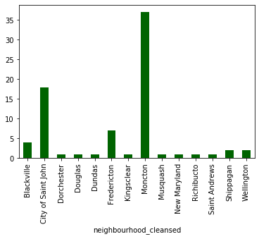

```python
#Create a bar chart with the data found in host_listings_count
host_listings['host_listings_count'].count().plot.bar(color='DarkGreen')
```

While the counts for each place are the same, this helps show the importance of addressing specific places over others.

With these places being identified, staff from each of these places can use use the criteria from above to decide on regulations for AirBnB. In particular, city staff in Moncton and the City of Saint John should investiage ways of regulating AirBnB to prevent negative impacts on their housing markets.

A final point should also be made about the host with 36 listings across New Brunswick. This data was not included in the final dataset because the rooms were labelled as 'hotel rooms'. However, these types of listings should be investigated further. It is unclear how, if at all, these listings would impact the housing market in New Brunswick.

References

Ferreri, M., Sanyal, R. (2018). Platform economies and urban planning: Airbnb and regulated deregulation in London. Urban Studies, 55(15), 3353-3368. Retrieved from: https://doi.dox.org/10.1177/0042098017751982

Inside Airbnb. (n.d.). About Inside Airbnb. Retrieved from: http://insideairbnb.com/about.html

Quatronne, G., Proserpio, D., Quercia, D., Capra, L., Musolesi, M. (2016). Proceeding of the 25th International Conference on the World Wide Web. 1385-1394. Retrieved from: https://doi.org/10.1145/2872427.2874815

Wegmann, J., Jiao, J. (2017). Taming Airbnb: Toward guiding principles for local regulation of urban vacation rentals based on empirical results from five US cities. Land Use Policy, 69(1), 494-501.